# script5_WGCNA_HuAgeDis_MSNDsplit_v1

### Step16: Pick soft power and detect modules in data A1

```r
#softPower estimate after 'goodSamplesgoodGenes' and variance based selection
#Pick power for the data A1
powers = c(c(1:10), seq(from = 12, to=40, by=2))
sftA1 = pickSoftThreshold(datExprA1g2, RsquaredCut=0.80, powerVector = powers, networkType="signed", moreNetworkConcepts=TRUE, verbose = 5, blockSize=5000)
```

```
##  pickSoftThreshold: calculating connectivity for given powers...
##    ..working on genes 1 through 784 of 784
```

```
##    Power SFT.R.sq   slope truncated.R.sq mean.k. median.k. max.k. Density
## 1      1  0.44000 42.7000          0.283  666.00    674.00  701.0 0.85100
## 2      2  0.42000 20.7000          0.255  569.00    580.00  628.0 0.72600
## 3      3  0.89300  7.2300          0.865  487.00    501.00  564.0 0.62200
## 4      4  0.92100  4.9100          0.911  418.00    433.00  507.0 0.53300
## 5      5  0.90200  3.7400          0.901  359.00    375.00  456.0 0.45900
## 6      6  0.86800  2.9700          0.880  310.00    325.00  411.0 0.39500
## 7      7  0.82300  2.3900          0.858  267.00    281.00  371.0 0.34200
## 8      8  0.73300  1.9700          0.821  232.00    244.00  335.0 0.29600
## 9      9  0.64600  1.5300          0.763  201.00    213.00  303.0 0.25600
## 10    10  0.55000  1.2300          0.712  174.00    185.00  274.0 0.22300
## 11    12  0.30300  0.7490          0.568  132.00    141.00  225.0 0.16900
## 12    14  0.09220  0.3480          0.465  101.00    107.00  185.0 0.12900
## 13    16  0.00191  0.0477          0.441   77.60     81.90  153.0 0.09910
## 14    18  0.03100 -0.1900          0.502   59.90     62.80  126.0 0.07650
```

[output cut: 37 more lines]

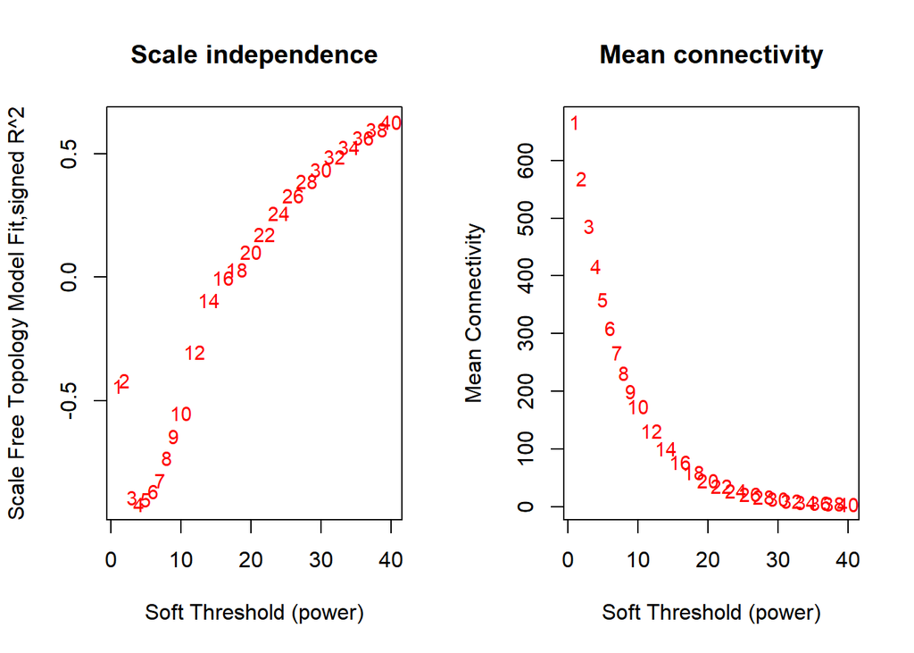

```r
par(mfrow = c(1,2));
cex1 = 0.9;
#scale-free topology fit index as function of soft-thresholding power
plot(sftA1$fitIndices[,1], -sign(sftA1$fitIndices[,3])*sftA1$fitIndices[,2],
xlab="Soft Threshold (power)",ylab="Scale Free Topology Model Fit,signed R^2",type="n",
main = paste("Scale independence"));
text(sftA1$fitIndices[,1], -sign(sftA1$fitIndices[,3])*sftA1$fitIndices[,2],
labels=powers,cex=cex1,col="red");
#this line corresponds to using R^2 cut-off of h
abline(h=0.90,col="red")
# Mean connectivity as a function of the soft-thresholding power
plot(sftA1$fitIndices[,1], sftA1$fitIndices[,5],
xlab="Soft Threshold (power)",ylab="Mean Connectivity", type="n",
main = paste("Mean connectivity"))
text(sftA1$fitIndices[,1], sftA1$fitIndices[,5], labels=powers, cex=cex1,col="red")
```

```r
dev.print(pdf, "Step16_plot_A1_auto-power_plot.pdf",height=10,width=18)
```

```r
#sftA1$powerEstimate is systems best guess
softPowerA1=sftA1$powerEstimate
softPowerA1
```

```
## [1] 3
```

```r
#set soft power to value 12 for signed networks if above automatic detection detects low power.
softPowerA1=12
```

```r
#Calculate weighted adjacency
adjacencyA1 = adjacency(t(datExprA1g2),power=softPowerA1,type="signed");
diag(adjacencyA1)=0
#Turn adjacency into topology overlap matrix
TOM=TOMsimilarity(adjacencyA1, TOMType="signed")
```

```
## ..connectivity..
## ..matrix multiplication (system BLAS)..
## ..normalization..
## ..done.
```

```r
dissTOMA1 = 1-TOM
#Hierarchial clustering based on TOM
geneTreeA1 = flashClust(as.dist(dissTOMA1), method="average")
```

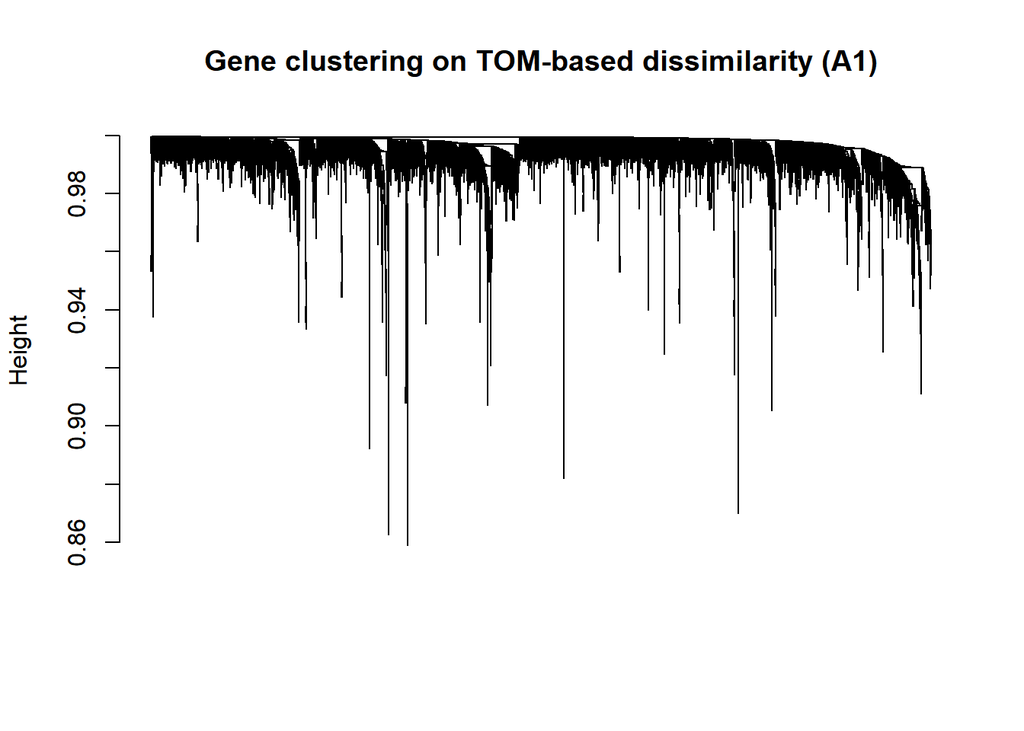

```r
#Display the networks visually:
#pdf("dendrogram.pdf",height=6,width=16)
#par(mar=c(1,1,1,1))
#par(mfrow=c(1,2))
plot(geneTreeA1,xlab="",sub="",main="Gene clustering on TOM-based dissimilarity (A1)",
labels=FALSE,hang=0.04);
```

```r
#dev.off()
dev.print(pdf,file="Step16_plot_dendrogram.pdf",height=5,width=10)
```

```r
#Modules for dataset A1 or modulesA1, cutHeight can be changed to adjust module size and reduce grey or unasigned module size based on cluster dendrogram plot height
mColorh=NULL
mColorhL=NULL
for (ds in 0:3){
tree = cutreeHybrid(dendro = geneTreeA1, pamStage=TRUE,
minClusterSize = (30-3*ds), cutHeight = 1.00,
deepSplit = ds, distM = dissTOMA1)
mColorh=cbind(mColorh,labels2colors(tree$labels));
mColorhL=cbind(mColorhL, paste("HuAgeMSNDsplit_", str_pad(tree$labels, 2, pad="0"), sep="" ))
}
```

```
##  ..done.
##  ..done.
##  ..done.
##  ..done.
```

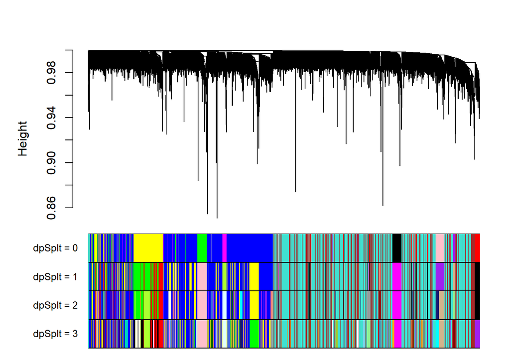

```r
#pdf("Module_choices.pdf", height=10,width=25);
plotDendroAndColors(geneTreeA1, mColorh, paste("dpSplt =",0:3), main = "",dendroLabels=FALSE);
```

```r
#dev.off()
dev.print(pdf,file="Step16_plot_Module_choices.pdf", height=5,width=10)
```

```r
#Picked deepSplit or dpSplit 2 which gives small number of large modules
modulesA1 = mColorh[,3] #color labels of modules
modulesA1L= mColorhL[,3] #numeric label of modules
#number of genes per module
```

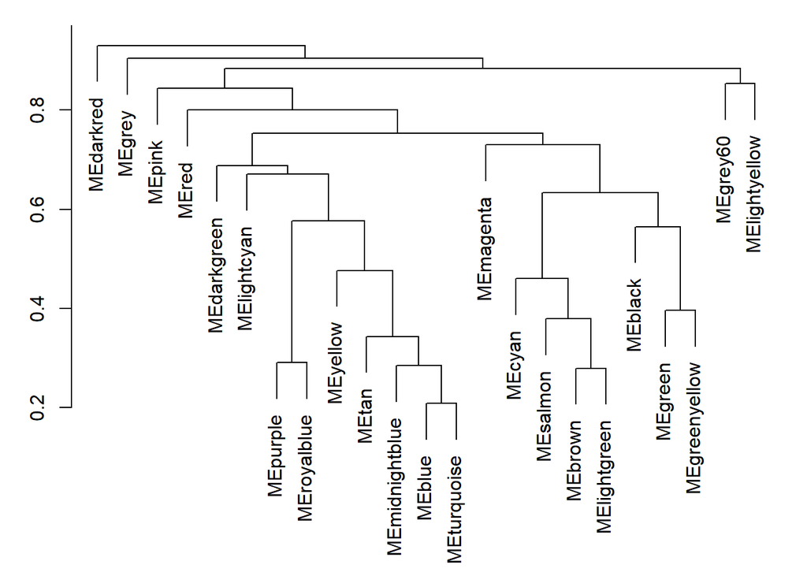

```r
#Principal component for visualization
PCs1A = moduleEigengenes(t(datExprA1g2), colors=modulesA1)
ME_1A = PCs1A$eigengenes
distPC1A = 1-abs(cor(ME_1A,use="p"))
distPC1A = ifelse(is.na(distPC1A), 0, distPC1A)
pcTree1A = hclust(as.dist(distPC1A),method="a")
MDS_1A = cmdscale(as.dist(distPC1A),2)
colorsA1 = names(table(modulesA1))

par(mfrow=c(1,1), mar=c(0, 3, 1, 1) + 0.1, cex=1)
plot(pcTree1A, xlab="",ylab="",main="",sub="")
```

```r
dev.print(pdf,file="Step16_plot_ModuleEigengeneVisualizationsTree.pdf",height=5,width=10)
```

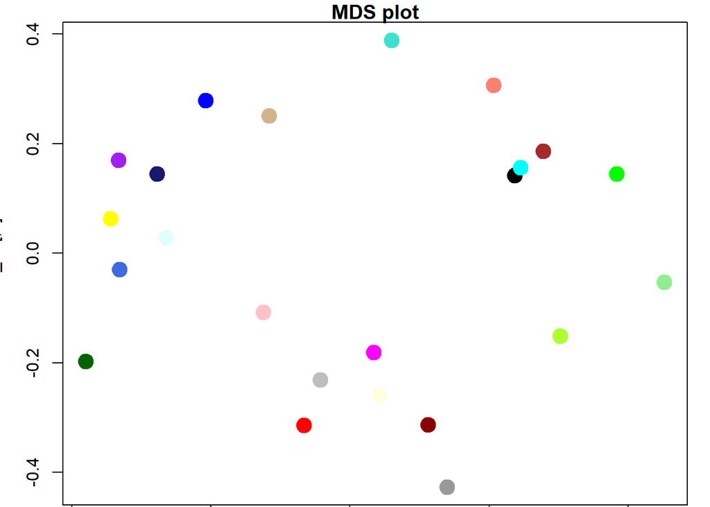

```r
par(mfrow=c(1,1), mar=c(0, 3, 1, 1) + 0.1, cex=1)
plot(MDS_1A, col= colorsA1, main="MDS plot", cex=2, pch=19)
```

```r
dev.print(pdf,file="Step16_plot_ModuleEigengeneVisualizationsMDS.pdf",height=5,width=5)
```

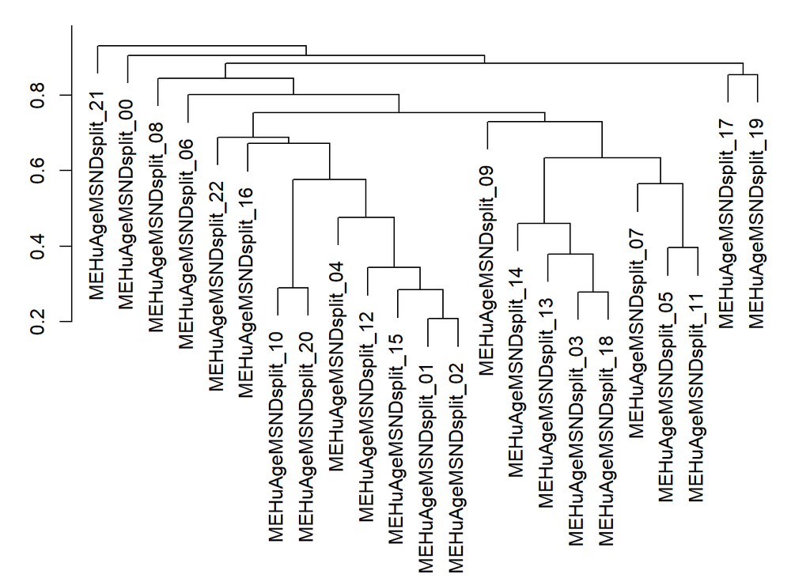

```r
PCs1AL = moduleEigengenes(t(datExprA1g2), colors=modulesA1L)
ME_1AL = PCs1AL$eigengenes
distPC1AL = 1-abs(cor(ME_1AL,use="p"))
distPC1AL = ifelse(is.na(distPC1AL), 0, distPC1AL)
pcTree1AL = hclust(as.dist(distPC1AL),method="a")
MDS_1AL = cmdscale(as.dist(distPC1AL),2)
colorsA1L = names(table(modulesA1L))

par(mfrow=c(1,1), mar=c(0, 3, 1, 1) + 0.1, cex=1)
plot(pcTree1AL, xlab="",ylab="",main="",sub="")
```

```r
dev.print(pdf,file="Step16_plot_ModuleEigengeneVisualizationsTreelabels.pdf",height=5,width=10)
```

```r
par(mfrow=c(1,1), mar=c(0, 3, 1, 1) + 0.1, cex=1)
#plot(MDS_1AL, col= colorsA1L, main="MDS plot", cex=2, pch=19)
#dev.print(pdf,file="Step16_plot_ModuleEigengeneVisualizationsMDSlabels.pdf",height=5,width=5)
```

### Step17A: Module membership (kME) for network comparison and identification of hub genes

```r
#kME to measure of correlations between each gene and each ME
#for data A1
geneModuleMembership1 = signedKME(t(datExprA1g2), ME_1A)
colnames(geneModuleMembership1)=paste("PC",colorsA1,".cor",sep="");
MMPvalue1=corPvalueStudent(as.matrix(geneModuleMembership1),dim(datExprA1g2)[[2]]);
colnames(MMPvalue1)=paste("PC",colorsA1,".pval",sep="");
Gene = rownames(datExprA1g2)
kMEtable1 = cbind(Gene,Gene,modulesA1)
for (i in 1:length(colorsA1))
kMEtable1 = cbind(kMEtable1, geneModuleMembership1[,i], MMPvalue1[,i])
colnames(kMEtable1)=c("PSID","Gene","Module",sort(c(colnames(geneModuleMembership1),
colnames(MMPvalue1))))
write.csv(kMEtable1,"Step17A_result_kMEtable1colors.csv")
```

```r
#Hub genes are genes that show significant correlation with MEs and high within-module connectivity
#kME values are used to compare data A1 to determine which genes have extremely high kME values in networks
#and are thus genes are hubs in both networks
#ref: modified from https://support.bioconductor.org/p/94701/
topGenesKME = NULL
for (c in 1:length(colorsA1)){
kMErank1 = rank(-geneModuleMembership1[,c])
#maxKMErank = rank(apply(cbind(kMErank1,kMErank2+.00001),1,max))
#topGenesKME = cbind(topGenesKME,Gene[maxKMErank<=10])
topGenesKME = cbind(topGenesKME,Gene[order(kMErank1, decreasing=FALSE)][1:10])
}
colnames(topGenesKME) = colorsA1
topGenesKME
```

```
##       black     blue       brown     cyan     darkgreen  darkred
##  [1,] "TCEB1"   "MAPKAPK2" "SULT4A1" "PECAM1" "SERPINA3" "PARK7"
##  [2,] "UQCRFS1" "IL17RB"   "SYNGR3"  "FLI1"   "CD44"     "PSMB7"
##  [3,] "COPS5"   "PRKD3"    "TAGLN3"  "GNG11"  "SERPINA5" "FKBP2"
##  [4,] "DDX1"    "INPPL1"   "ACOT7"   "CLDN5"  "TPST1"    "CUTA"
##  [5,] "PSMD10"  "STK38"    "AMPH"    "PODXL"  "GBP2"     "GPX1"
##  [6,] "ATP5O"   "ZNF217"   "NEFL"    "ICAM2"  "CHI3L1"   "TUFM"
##  [7,] "UQCRH"   "FBXL7"    "INA"     "PRKCH"  "CNN3"     "GUK1"
##  [8,] "SLC25A5" "NFKB1"    "STMN2"   "FOXF2"  "F3"       "RPL36AL"
##  [9,] "COX5A"   "RAF1"     "AP3B2"   "VWF"    "CHI3L2"   "ATP5A1"
## [10,] "SSBP1"   "ITGB5"    "SNX10"   "SLC2A1" "DTNA"     "TPI1"
##       green     greenyellow grey       grey60    lightcyan  lightgreen
##  [1,] "TMC6"    "MYO18A"    "TRIP11"   "ARL6IP5" "CHORDC1"  "DDC"
##  [2,] "MAP3K11" "LTBP3"     "SSTR2"    "TOP1"    "BAG3"     "DLK1"
##  [3,] "ERBB3"   "TRIM28"    "KPNA5"    "ATP6V1D" "SPR"      "SLC6A3"
```

[output cut: 29 more lines]

```r
write.csv(topGenesKME,"Step17A_result_A1_HubGenestopGenesKMEcolorsRankSorted.csv")
#These genes or probes represent the top 10 hub genes for modules in data A1 networks.
```

```r
#Hub genes are genes that show significant correlation with MEs and high within-module connectivity
#kME values are used to compare data A1 to determine which genes have extremely high kME values in networks
#and are thus genes are hubs in both networks
topGenesKME = NULL
for (c in 1:length(colorsA1)){
kMErank1 = rank(-geneModuleMembership1[,c])
maxKMErank = rank(apply(cbind(kMErank1),1,max))
#maxKMErank = rank(apply(cbind(kMErank1,kMErank2+.00001),1,max))
topGenesKME = cbind(topGenesKME,Gene[maxKMErank<=10])
}
colnames(topGenesKME) = colorsA1
topGenesKME
```

```
##       black     blue       brown     cyan     darkgreen  darkred
##  [1,] "UQCRH"   "IL17RB"   "STMN2"   "VWF"    "SERPINA3" "GPX1"
##  [2,] "ATP5O"   "ITGB5"    "NEFL"    "CLDN5"  "CHI3L1"   "FKBP2"
##  [3,] "COX5A"   "ZNF217"   "SYNGR3"  "PODXL"  "CHI3L2"   "TPI1"
##  [4,] "UQCRFS1" "PRKD3"    "INA"     "ICAM2"  "CD44"     "ATP5A1"
##  [5,] "TCEB1"   "FBXL7"    "ACOT7"   "PECAM1" "SERPINA5" "RPL36AL"
##  [6,] "SLC25A5" "INPPL1"   "SULT4A1" "GNG11"  "F3"       "GUK1"
##  [7,] "SSBP1"   "MAPKAPK2" "AMPH"    "FLI1"   "GBP2"     "PARK7"
##  [8,] "PSMD10"  "STK38"    "SNX10"   "SLC2A1" "DTNA"     "CUTA"
##  [9,] "DDX1"    "NFKB1"    "TAGLN3"  "FOXF2"  "CNN3"     "PSMB7"
## [10,] "COPS5"   "RAF1"     "AP3B2"   "PRKCH"  "TPST1"    "TUFM"
##       green     greenyellow grey       grey60    lightcyan  lightgreen
##  [1,] "CDKN1C"  "APLP1"     "SCN8A"    "PPIG"    "HSPA1A"   "SLC18A2"
##  [2,] "ERBB3"   "LTBP3"     "CDC42EP3" "TMEM5"   "BAG3"     "DDC"
##  [3,] "SH3BP4"  "PTOV1"     "ZFPM2"    "ATG12"   "DNAJB1"   "SLC6A3"
```

[output cut: 29 more lines]

```r
write.csv(topGenesKME,"Step17A_result_A1_HubGenestopGenesKMEcolorsRankUnsorted.csv")
#These genes or probes represent the top 10 hub genes for modules in data A1 networks.
```

# Same as above for labeled modules

```r
#kME to measure of correlations between each gene and each ME
#for data A1
geneModuleMembership1L = signedKME(t(datExprA1g2), ME_1AL)
colnames(geneModuleMembership1L)=paste("PC",colorsA1L,".cor",sep="");
MMPvalue1L=corPvalueStudent(as.matrix(geneModuleMembership1L),dim(datExprA1g2)[[2]]);
colnames(MMPvalue1L)=paste("PC",colorsA1L,".pval",sep="");
GeneL = rownames(datExprA1g2)
kMEtable1L = cbind(GeneL,GeneL,modulesA1L)
for (i in 1:length(colorsA1L))
kMEtable1L = cbind(kMEtable1L, geneModuleMembership1L[,i], MMPvalue1L[,i])
colnames(kMEtable1L)=c("PSID","Gene","Module",sort(c(colnames(geneModuleMembership1L),
colnames(MMPvalue1L))))
write.csv(kMEtable1L,"Step17A_result_kMEtable1labels.csv")
```

```r
#Hub genes are genes that show significant correlation with MEs and high within-module connectivity
#kME values are used to compare data A1 to determine which genes have extremely high kME values in networks
#and are thus genes are hubs in both networks
#ref: modified from https://support.bioconductor.org/p/94701/
topGenesKMEL = NULL
for (c in 1:length(colorsA1L)){
kMErank1L = rank(-geneModuleMembership1L[,c])
#maxKMErank = rank(apply(cbind(kMErank1,kMErank2+.00001),1,max))
#topGenesKMEL = cbind(topGenesKMEL,GeneL[maxKMErankL<=10])
topGenesKMEL = cbind(topGenesKMEL,GeneL[order(kMErank1L, decreasing=FALSE)][1:10])
}
colnames(topGenesKMEL) = colorsA1L
topGenesKMEL
```

```
##       HuAgeMSNDsplit_00 HuAgeMSNDsplit_01 HuAgeMSNDsplit_02
##  [1,] "TRIP11"          "GOT1"            "MAPKAPK2"
##  [2,] "SSTR2"           "DYNC1I1"         "IL17RB"
##  [3,] "KPNA5"           "COPS4"           "PRKD3"
##  [4,] "NR3C1"           "GNG3"            "INPPL1"
##  [5,] "MATN1"           "MOAP1"           "STK38"
##  [6,] "SCN8A"           "CMAS"            "ZNF217"
##  [7,] "ZFPM2"           "NDUFAB1"         "FBXL7"
##  [8,] "HUS1"            "MDH2"            "NFKB1"
##  [9,] "CDC42EP3"        "COPS7A"          "RAF1"
## [10,] "XPC"             "PCMT1"           "ITGB5"
##       HuAgeMSNDsplit_03 HuAgeMSNDsplit_04 HuAgeMSNDsplit_05
##  [1,] "SULT4A1"         "LCP1"            "TMC6"
##  [2,] "SYNGR3"          "FCGR2A"          "MAP3K11"
##  [3,] "TAGLN3"          "CYBA"            "ERBB3"
```

[output cut: 73 more lines]

```r
write.csv(topGenesKMEL,"Step17A_result_A1_HubGenestopGenesKMElabelsRankSorted.csv")
#These genes or probes represent the top 10 hub genes for modules in data A1 networks.
```

```r
#Hub genes are genes that show significant correlation with MEs and high within-module connectivity
#kME values are used to compare data A1 to determine which genes have extremely high kME values in networks
#and are thus genes are hubs in both networks
topGenesKMEL = NULL
for (c in 1:length(colorsA1L)){
kMErank1L = rank(-geneModuleMembership1L[,c])
maxKMErankL = rank(apply(cbind(kMErank1L),1,max))
#maxKMErank = rank(apply(cbind(kMErank1,kMErank2+.00001),1,max))
topGenesKMEL = cbind(topGenesKMEL,GeneL[maxKMErankL<=10])
}
colnames(topGenesKMEL) = colorsA1L
topGenesKMEL
```

```
##       HuAgeMSNDsplit_00 HuAgeMSNDsplit_01 HuAgeMSNDsplit_02
##  [1,] "SCN8A"           "GNG3"            "IL17RB"
##  [2,] "CDC42EP3"        "DYNC1I1"         "ITGB5"
##  [3,] "ZFPM2"           "MOAP1"           "ZNF217"
##  [4,] "MATN1"           "GOT1"            "PRKD3"
##  [5,] "SSTR2"           "COPS4"           "FBXL7"
##  [6,] "NR3C1"           "NDUFAB1"         "INPPL1"
##  [7,] "KPNA5"           "CMAS"            "MAPKAPK2"
##  [8,] "HUS1"            "PCMT1"           "STK38"
##  [9,] "TRIP11"          "MDH2"            "NFKB1"
## [10,] "XPC"             "COPS7A"          "RAF1"
##       HuAgeMSNDsplit_03 HuAgeMSNDsplit_04 HuAgeMSNDsplit_05
##  [1,] "STMN2"           "C1QA"            "CDKN1C"
##  [2,] "NEFL"            "FCGR2A"          "ERBB3"
##  [3,] "SYNGR3"          "TYROBP"          "SH3BP4"
```

[output cut: 73 more lines]

```r
write.csv(topGenesKMEL,"Step17A_result_A1_HubGenestopGenesKMElabelsRankUnsorted.csv")
#These genes or probes represent the top 10 hub genes for modules in data A1 networks.
```

### Step17B: Intramodular connectivity (kIM or kWithin) and whole network connectivity (kTotal) for network comparison

```r
#Ref: WGCNA tutorial Steve Horvath Peter Langfelder 2011
#intramodular connectivity is mathematically the sum of module edge weights or "degree" of connectivity between a given node or gene and other genes or nodes within the module.
#For colors
IntraModularConnectivity1=intramodularConnectivity(adjacencyA1,modulesA1)
```

```r
#We get the color labels for the genes
GeneModule1=kMEtable1[,c("PSID","Gene","Module")]
rownames(GeneModule1)=rownames(kMEtable1)
```

```r
#merge the intramodular connectivity dataframe with module names by rownames that are gene symbols
IntraModularConnectivity2=merge(GeneModule1,IntraModularConnectivity1, by="row.names")
#drop the extra row.name column
IntraModularConnectivity3=IntraModularConnectivity2[,-c(1)]
DT::datatable(head(IntraModularConnectivity3))
```

|  | PSID | Gene | Module | kTotal | kWithin | kOut | kDiff |
| --- | --- | --- | --- | --- | --- | --- | --- |
| 1 | A2M | A2M | cyan | 3.7043814435993 | 0.506940127132344 | 3.19744131646696 | -2.69050118933462 |
| 2 | A4GALT | A4GALT | blue | 4.39028363628473 | 1.89022933693358 | 2.50005429935115 | -0.609824962417576 |
| 3 | A4GNT | A4GNT | blue | 2.28774575228328 | 0.551095515620032 | 1.73665023666325 | -1.18555472104322 |
| 4 | AAAS | AAAS | salmon | 3.20471431343011 | 0.144008775214661 | 3.06070553821545 | -2.91669676300079 |
| 5 | AADAC | AADAC | turquoise | 2.25385445167286 | 0.768025695146394 | 1.48582875652646 | -0.717803061380071 |
| 6 | AAMP | AAMP | magenta | 4.91362651765532 | 0.906328233804085 | 4.00729828385124 | -3.10097005004715 |

```r
#export kWithin and kTotal for all genes
write.csv(IntraModularConnectivity3,"Step17B_result_kWithintable1colors.csv")
```

```r
#Abbreviation IntraModularConnectivity3=IMC3
IMC3=IntraModularConnectivity3

#Export genes ranked by Intramodular connectivity for each module
for (i in unique(IMC3$Module)){

  #Select modules
  modules= i
  modules

  #net gene Connectivity or weights is a.k.a. kIM or IM or kWithin
  IMC3_sel=IMC3[which(IMC3$Module==modules),] #select those rows which match module name
  IMC3_sort=IMC3_sel[order(-IMC3_sel$kWithin),] #order by stronger to weaker connectivity

  #net gene Connectivity ranks
  IMC3_sort$rank<- rank(-(IMC3_sort$kWithin)) #This gives the highest kWithin the highest rank
  #export output
  write.table(IMC3_sort, paste0("ForGenesInModule-", modules, "-RankedByIntraModularConnectivity3.txt", sep=""),row.names=F, quote=F)
}
```

# Same as above for labeled modules

```r
#Ref: WGCNA tutorial Steve Horvath Peter Langfelder 2011
#intramodular connectivity is mathematically the sum of module edge weights or "degree" of connectivity between a given node or gene and other genes or nodes within the module.
#For colors
IntraModularConnectivity1L=intramodularConnectivity(adjacencyA1,modulesA1L)
```

```r
#We get the number labels for the genes
GeneModule1L=kMEtable1L[,c("PSID","Gene","Module")]
rownames(GeneModule1L)=rownames(kMEtable1L)
```

```r
#merge the intramodular connectivity dataframe with module names by rownames that are gene symbols
IntraModularConnectivity2L=merge(GeneModule1L,IntraModularConnectivity1L, by="row.names")
#drop the extra row.name column
IntraModularConnectivity3L=IntraModularConnectivity2L[,-c(1)]
DT::datatable(head(IntraModularConnectivity3L))
```

|  | PSID | Gene | Module | kTotal | kWithin | kOut | kDiff |
| --- | --- | --- | --- | --- | --- | --- | --- |
| 1 | A2M | A2M | HuAgeMSNDsplit_14 | 3.7043814435993 | 0.506940127132344 | 3.19744131646696 | -2.69050118933462 |
| 2 | A4GALT | A4GALT | HuAgeMSNDsplit_02 | 4.39028363628473 | 1.89022933693358 | 2.50005429935115 | -0.609824962417576 |
| 3 | A4GNT | A4GNT | HuAgeMSNDsplit_02 | 2.28774575228328 | 0.551095515620032 | 1.73665023666325 | -1.18555472104322 |
| 4 | AAAS | AAAS | HuAgeMSNDsplit_13 | 3.20471431343011 | 0.144008775214661 | 3.06070553821545 | -2.91669676300079 |
| 5 | AADAC | AADAC | HuAgeMSNDsplit_01 | 2.25385445167286 | 0.768025695146394 | 1.48582875652646 | -0.717803061380071 |
| 6 | AAMP | AAMP | HuAgeMSNDsplit_09 | 4.91362651765532 | 0.906328233804085 | 4.00729828385124 | -3.10097005004715 |

```r
#export kWithin and kTotal for all genes
write.csv(IntraModularConnectivity3L,"Step17B_result_kWithintable1labels.csv")
```

```r
#Abbreviation IntraModularConnectivity3L=IMC3L
IMC3L=IntraModularConnectivity3L

#Export genes ranked by Intramodular connectivity for each module
for (i in unique(IMC3L$Module)){

  #Select modules
  modules= i
  modules

  #net gene Connectivity or weights is a.k.a. kIM or IM or kWithin
  IMC3L_sel=IMC3L[which(IMC3L$Module==modules),] #select those rows which match module name
  IMC3L_sort=IMC3L_sel[order(-IMC3L_sel$kWithin),] #order by stronger to weaker connectivity

  #net gene Connectivity ranks
  IMC3L_sort$rank<- rank(-(IMC3L_sort$kWithin)) #This gives the highest kWithin the highest rank
  #export output
  write.table(IMC3L_sort, paste0("ForGenesInModule-", modules, "-RankedByIntraModularConnectivity3L.txt", sep=""),row.names=F, quote=F)
}
```

### Step18: Generating individual txt files containing genes in a given module

```r
#Make a folder first called 'Module_GeneskMEHubs' change full path below as per your system
dir.create("./Module_GeneskMEHubs")
folder = "Module_GeneskMEHubs/"
for (c in colorsA1){
fn = paste(folder, c, ".txt",sep="");
write.geneList(Gene[modulesA1==c], fn)
};
write(Gene,paste(folder,"all.txt",sep=""))
#The folder should now have files titled "<color>.txt" that contain the gene names of every gene in that module,as well as a file titled "all.txt" that has every gene in your data set.
```

```r
#make a summary file of all the genes in modules, similar to kME files but with only genes and module names as above
geneListsModuleSummary=cbind(Gene,modulesA1)
write.csv(geneListsModuleSummary,"Step18_result_geneListsModuleSummarycolors.csv")
```

# Same as above for labeled modules

```r
#Make a folder first called 'Module_GeneskMEHubs' change full path below as per your system
folder = "Module_GeneskMEHubs/"
for (c in colorsA1L){
fn = paste(folder, c, ".txt",sep="");
write.geneList(GeneL[modulesA1L==c], fn)
};
write(GeneL,paste(folder,"allL.txt",sep=""))
#The folder should now have files titled "<color>.txt" that contain the gene names of every gene in that module,as well as a file titled "all.txt" that has every gene in your data set.
```

```r
#make a summary file of all the genes in modules, similar to kME files but with only genes and module names as above
geneListsModuleSummaryL=cbind(GeneL,modulesA1L)
write.csv(geneListsModuleSummaryL,"Step18_result_geneListsModuleSummarylabels.csv")
```

### Step19: Visualization of trait module relatonships for data A1

# In this step we use the coded metadata files

# Relating modules to physiological traits for A1

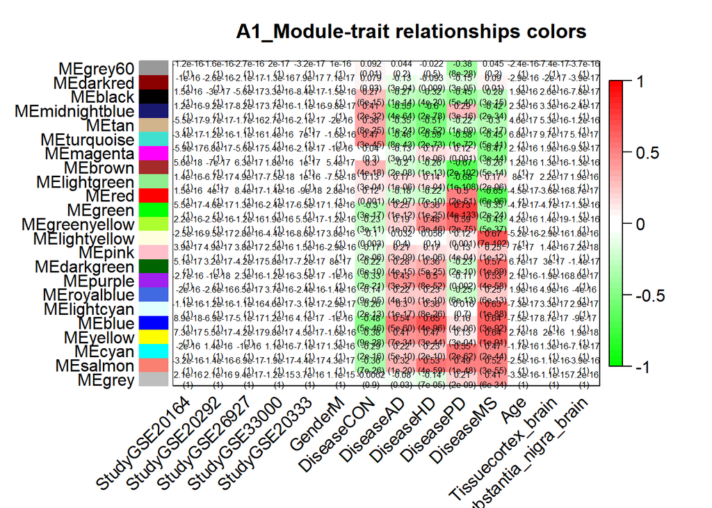

```r
# For data A1
# Define numbers of genes and samples
nGenesA1 = nrow(datExprA1g2)
nSamplesA1 = ncol(datExprA1g2)
# Recalculate MEs with color labels
MEs0A1= moduleEigengenes(t(datExprA1g2),modulesA1)$eigengenes
MEsA1= orderMEs(MEs0A1)
modTraitCorA1 = cor(MEsA1, metadataA1g_coded, use = "p")
modTraitPA1 = corPvalueStudent(modTraitCorA1, nSamplesA1)
textMatrixA1 = paste(signif(modTraitCorA1, 2), "\n(",
signif(modTraitPA1, 1), ")", sep = "")
dim(textMatrixA1) = dim(modTraitCorA1)
par(mar = c(6, 8.5, 3, 3))
# Display the correlation values within a heatmap plot
labeledHeatmap(Matrix = modTraitCorA1, xLabels = names(metadataA1g_coded),
yLabels = names(MEsA1), ySymbols = names(MEsA1),
colorLabels =FALSE,colors=greenWhiteRed(50),textMatrix=textMatrixA1,
setStdMargins = FALSE, cex.text = 0.5, zlim = c(-1,1),
main = paste("A1_Module-trait relationships colors"))
```

```r
dev.print(pdf,"Step19_plot_A1_relating modules to trait colors.pdf", width=5, height=5)
```

```r
#This is for color module trait table
colnames(modTraitPA1) = paste("p.value.", colnames(modTraitCorA1), sep="");
out3<-cbind(Module=rownames(modTraitCorA1), modTraitCorA1, modTraitPA1)
dim(out3)
```

```
## [1] 23 29
```

```r
write.table(out3, "Step19_result_A1_relating modules to trait colors.csv", sep=",",row.names=F)
```

# Same as above for labeled modules

# Relating modules to physiological traits for A1

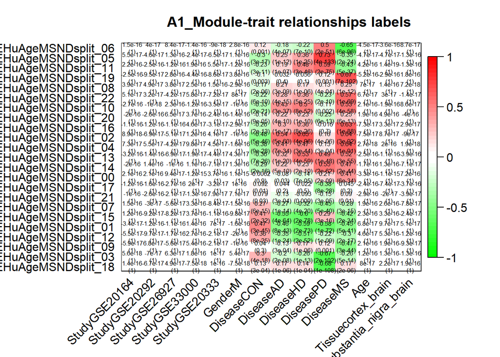

```r
# For data A1
# Define numbers of genes and samples
nGenesA1L = nrow(datExprA1g2)
nSamplesA1L = ncol(datExprA1g2)
# Recalculate MEs with color labels
MEs0A1L= moduleEigengenes(t(datExprA1g2),modulesA1L)$eigengenes
MEsA1L= orderMEs(MEs0A1L)
modTraitCorA1L = cor(MEsA1L, metadataA1g_coded, use = "p")
modTraitPA1L = corPvalueStudent(modTraitCorA1L, nSamplesA1L)
textMatrixA1L = paste(signif(modTraitCorA1L, 2), "\n(",
signif(modTraitPA1L, 1), ")", sep = "")
dim(textMatrixA1L) = dim(modTraitCorA1L)
par(mar = c(6, 8.5, 3, 3))
# Display the correlation values within a heatmap plot
labeledHeatmap(Matrix = modTraitCorA1L, xLabels = names(metadataA1g_coded),
yLabels = names(MEsA1L), ySymbols = names(MEsA1L),
colorLabels =FALSE,colors=greenWhiteRed(50),textMatrix=textMatrixA1L,
setStdMargins = FALSE, cex.text = 0.5, zlim = c(-1,1),
main = paste("A1_Module-trait relationships labels"))
```

```r
dev.print(pdf,"Step19_plot_A1_relating modules to trait labels.pdf", width=5, height=5)
```

```r
#This is for label module trait table
colnames(modTraitPA1L) = paste("p.value.", colnames(modTraitCorA1L), sep="");
out3L<-cbind(Module=rownames(modTraitCorA1L), modTraitCorA1L, modTraitPA1L)
dim(out3L)
```

```
## [1] 23 29
```

```r
write.table(out3L, "Step19_result_A1_relating modules to trait labels.csv", sep=",",row.names=F)
```

```r
#save.image(file="temp.RData")
#rm(list=ls())
#gc()
#To reload uncomment code below
#load(file="temp.RData")
```

### Step20: Cross-pipeline preservation and hypergeometric test: Qualitatively and quantitatively measure cross-species, cross-pipeline and/or any cross-dataset network preservation at the module level

# Will export the files for preservation analysis and hypergeometric test

```r
#Export expression file
write.csv(datExprA1g2,"Step20_result_ForPres&Hyper_HuAgeMSNDsplit_datExprA1g2.csv")
#Export the module and gene names for use Preservation and hypergeometric test
write.csv(kMEtable1[,c("PSID","Gene","Module")],"Step20_result_ForPres&Hyper_HuAgeMSNDsplit_GeneModule.csv")
write.csv(kMEtable1L[,c("PSID","Gene","Module")],"Step20_result_ForPres&Hyper_HuAgeMSNDsplit_GeneModuleL.csv")
```

### Step21A: Enrichment of cell types in modules

```r
celltype=read.csv("./InputMetadata&Lists/CellType_ImmuneCells_StemCells_Full_Hu.csv",sep=',')
cellTypeGeneCount=as.data.frame(table(celltype$Category))
cellTypeGeneCount
```

```
##                                        Var1 Freq
## 1                   aNP_BY_qRP_ThanTrong_up   68
## 2                   aRG_BY_qRG_ThanTrong_up  113
## 3                               astroBYoFC5 1078
## 4     AstroByothers_Zhang_Cuffdiff2FCover20  455
## 5                                endoBYoFC5  368
## 6   EndotheByothers_Zhang_Cuffdiff2FCover20  603
## 7      MacroByMicro_Zhang_Cuffdiff2FCover20  219
## 8                         macrophagesBYoFC5  394
## 9      MicroByMacro_Zhang_Cuffdiff2FCover20  460
## 10      MicroByMono_Zhang_Cuffdiff2FCover20  457
## 11                          microgliaBYoFC5  274
## 12 MicrogliByothers_Zhang_Cuffdiff2FCover20 1162
## 13      MonoByMicro_Zhang_Cuffdiff2FCover20  809
## 14                          monocytesBYoFC5  373
```

[output cut: 22 more lines]

```r
write.csv(cellTypeGeneCount,"CellType_ImmuneCells_StemCells_Full_Hu_GeneCount.csv")
```

```r
#This is the actual calulation of hypergeometric enrichment
enrichmentsCellTypeFullHuman = userListEnrichment(rownames(datExprA1g2), modulesA1,"./InputMetadata&Lists/CellType_ImmuneCells_StemCells_Full_Hu.csv", "", "enrichmentsCellTypeFullHuman_Sigificantcolors.csv")
```

```
## 792 comparisons were successfully performed.
```

```r
#List of genes that overlap between modules and CellTypeFullHuman
enrichmentsCellTypeFullHuman_OvGenes=enrichmentsCellTypeFullHuman[[2]]
dir.create("./enrichmentsCellTypeFullHuman_OvGenes")
for (i in 1:length(enrichmentsCellTypeFullHuman_OvGenes)) {
  write.csv(enrichmentsCellTypeFullHuman_OvGenes[i], file=paste0("enrichmentsCellTypeFullHuman_OvGenes/", names(enrichmentsCellTypeFullHuman_OvGenes)[i], ".txt"))
}

#List of genes that overlap between modules and CellTypeFullHuman
enrichmentsCellTypeFullHuman_NumOvGenes_pvalue=enrichmentsCellTypeFullHuman[[1]]
write.csv(enrichmentsCellTypeFullHuman_NumOvGenes_pvalue,"enrichmentsCellTypeFullHuman_NumOvGenes_pvalue_colors.csv")
```

```r
geneListsModuleSummary=read.csv('Step18_result_geneListsModuleSummarycolors.csv', sep=',')
enrichmentsSummaryCellTypeFullHuman=read.csv('enrichmentsCellTypeFullHuman_NumOvGenes_pvalue_colors.csv', sep=',')
```

```r
geneListsModuleSummaryMod=table(geneListsModuleSummary$modulesA1)
geneListsModuleSummaryMod=as.data.frame(geneListsModuleSummaryMod)
write.csv(geneListsModuleSummaryMod, "geneListsModuleSummarycolors_GeneCount.csv")

colnames(geneListsModuleSummaryMod)=c("InputCategories", "Freq")
geneListsModuleSummaryMod
```

```
##    InputCategories Freq
## 1            black  194
## 2             blue 1486
## 3            brown  783
## 4             cyan   99
## 5        darkgreen   29
## 6          darkred   37
## 7            green  297
## 8      greenyellow  134
## 9             grey    2
## 10          grey60   80
## 11       lightcyan   80
## 12      lightgreen   66
## 13     lightyellow   53
## 14         magenta  172
## 15    midnightblue   99
## 16            pink  186
## 17          purple  139
## 18             red  245
## 19       royalblue   52
## 20          salmon  107
## 21             tan  108
## 22       turquoise 2141
## 23          yellow  335
```

```r
enrichmentsSummaryCellTypeFullHumanmergeMod=merge(enrichmentsSummaryCellTypeFullHuman,geneListsModuleSummaryMod, by="InputCategories")
write.csv(enrichmentsSummaryCellTypeFullHumanmergeMod,"enrichmentsSummaryCellTypeFullHumanmergeMod_colors.csv")
```

# Same as above for labeled modules

```r
enrichmentsCellTypeFullHumanL = userListEnrichment(rownames(datExprA1g2), modulesA1L,"./InputMetadata&Lists/CellType_ImmuneCells_StemCells_Full_Hu.csv", "", "enrichmentsCellTypeFullHuman_Sigificantlabels.csv")
```

```
## 828 comparisons were successfully performed.
```

```r
#List of genes that overlap between modules and CellTypeFullHuman
enrichmentsCellTypeFullHuman_OvGenesL=enrichmentsCellTypeFullHumanL[[2]]
for (i in 1:length(enrichmentsCellTypeFullHuman_OvGenesL)) {
  write.csv(enrichmentsCellTypeFullHuman_OvGenesL[i], file=paste0("enrichmentsCellTypeFullHuman_OvGenes/", names(enrichmentsCellTypeFullHuman_OvGenesL)[i], ".txt"))
}

#List of genes that overlap between modules and CellTypeFullHuman
enrichmentsCellTypeFullHuman_NumOvGenes_pvalueL=enrichmentsCellTypeFullHumanL[[1]]
write.csv(enrichmentsCellTypeFullHuman_NumOvGenes_pvalueL,"enrichmentsCellTypeFullHuman_NumOvGenes_pvalue_labels.csv")
```

```r
geneListsModuleSummaryL=read.csv('Step18_result_geneListsModuleSummarylabels.csv', sep=',')
enrichmentsSummaryCellTypeFullHumanL=read.csv('enrichmentsCellTypeFullHuman_NumOvGenes_pvalue_labels.csv', sep=',')
```

```r
geneListsModuleSummaryModL=table(geneListsModuleSummaryL$modulesA1L)
geneListsModuleSummaryModL=as.data.frame(geneListsModuleSummaryModL)
write.csv(geneListsModuleSummaryModL, "geneListsModuleSummarylabels_GeneCount.csv")

colnames(geneListsModuleSummaryModL)=c("InputCategories", "Freq")
enrichmentsSummaryCellTypeFullHumanmergeModL=merge(enrichmentsSummaryCellTypeFullHumanL,geneListsModuleSummaryModL, by="InputCategories")
write.csv(enrichmentsSummaryCellTypeFullHumanmergeModL,"enrichmentsSummaryCellTypeFullHumanmergeModL_labels.csv")
```

DEGup enrichment in modules

### Step21B: Enrichment test for comparison with Cuffdiff2 defined DEGup signature genes

```r
#This is the actual calulation of hypergeometric enrichment
enrichmentsDEGup = userListEnrichment(rownames(datExprA1g2), modulesA1,"./InputMetadata&Lists/Disease_Microarray_DEGup_FC1.25_Signature.csv", "", "enrichmentsDEGup_Sigificantcolors.csv")
```

```
## 88 comparisons were successfully performed.
```

```r
#List of genes that overlap between modules and DEGup
enrichmentsDEGup_OvGenes=enrichmentsDEGup[[2]]
dir.create("./enrichmentsDEGup_OvGenes")
for (i in 1:length(enrichmentsDEGup_OvGenes)) {
  write.csv(enrichmentsDEGup_OvGenes[i], file=paste0("enrichmentsDEGup_OvGenes/", names(enrichmentsDEGup_OvGenes)[i], ".txt"))
}

#List of genes that overlap between modules and DEGup
enrichmentsDEGup_NumOvGenes_pvalue=enrichmentsDEGup[[1]]
write.csv(enrichmentsDEGup_NumOvGenes_pvalue,"enrichmentsDEGup_NumOvGenes_pvalue_colors.csv")
```

```r
geneListsModuleSummary=read.csv('Step18_result_geneListsModuleSummarycolors.csv', sep=',')
enrichmentsSummaryDEGup=read.csv('enrichmentsDEGup_NumOvGenes_pvalue_colors.csv', sep=',')
```

```r
geneListsModuleSummaryMod=table(geneListsModuleSummary$modulesA1)
geneListsModuleSummaryMod=as.data.frame(geneListsModuleSummaryMod)
write.csv(geneListsModuleSummaryMod, "geneListsModuleSummarycolors_GeneCount.csv")

colnames(geneListsModuleSummaryMod)=c("InputCategories", "Freq")
geneListsModuleSummaryMod
```

```
##    InputCategories Freq
## 1            black  194
## 2             blue 1486
## 3            brown  783
## 4             cyan   99
## 5        darkgreen   29
## 6          darkred   37
## 7            green  297
## 8      greenyellow  134
## 9             grey    2
## 10          grey60   80
## 11       lightcyan   80
## 12      lightgreen   66
## 13     lightyellow   53
## 14         magenta  172
## 15    midnightblue   99
## 16            pink  186
## 17          purple  139
## 18             red  245
## 19       royalblue   52
## 20          salmon  107
## 21             tan  108
## 22       turquoise 2141
## 23          yellow  335
```

```r
enrichmentsSummaryDEGupmergeMod=merge(enrichmentsSummaryDEGup,geneListsModuleSummaryMod, by="InputCategories")
write.csv(enrichmentsSummaryDEGupmergeMod,"enrichmentsSummaryDEGupmergeMod_colors.csv")
```

# Same as above for labeled modules

```r
enrichmentsDEGupL = userListEnrichment(rownames(datExprA1g2), modulesA1L,"./InputMetadata&Lists/Disease_Microarray_DEGup_FC1.25_Signature.csv", "", "enrichmentsDEGup_Sigificantlabels.csv")
```

```
## 92 comparisons were successfully performed.
```

```r
#List of genes that overlap between modules and DEGup
enrichmentsDEGup_OvGenesL=enrichmentsDEGupL[[2]]
for (i in 1:length(enrichmentsDEGup_OvGenesL)) {
  write.csv(enrichmentsDEGup_OvGenesL[i], file=paste0("enrichmentsDEGup_OvGenes/", names(enrichmentsDEGup_OvGenesL)[i], ".txt"))
}

#List of genes that overlap between modules and DEGup
enrichmentsDEGup_NumOvGenes_pvalueL=enrichmentsDEGupL[[1]]
write.csv(enrichmentsDEGup_NumOvGenes_pvalueL,"enrichmentsDEGup_NumOvGenes_pvalue_labels.csv")
```

```r
geneListsModuleSummaryL=read.csv('Step18_result_geneListsModuleSummarylabels.csv', sep=',')
enrichmentsSummaryDEGupL=read.csv('enrichmentsDEGup_NumOvGenes_pvalue_labels.csv', sep=',')
```

```r
geneListsModuleSummaryModL=table(geneListsModuleSummaryL$modulesA1L)
geneListsModuleSummaryModL=as.data.frame(geneListsModuleSummaryModL)
write.csv(geneListsModuleSummaryModL, "geneListsModuleSummarylabels_GeneCount.csv")

colnames(geneListsModuleSummaryModL)=c("InputCategories", "Freq")
enrichmentsSummaryDEGupmergeModL=merge(enrichmentsSummaryDEGupL,geneListsModuleSummaryModL, by="InputCategories")
write.csv(enrichmentsSummaryDEGupmergeModL,"enrichmentsSummaryDEGupmergeModL_labels.csv")
```

DEGupCON enrichment in modules

### Step21C: Enrichment test for comparison with Cuffdiff2 defined DEGupCON signature genes

```r
#This is the actual calulation of hypergeometric enrichment
enrichmentsDEGupCON = userListEnrichment(rownames(datExprA1g2), modulesA1,"./InputMetadata&Lists/Disease_Microarray_DEGupCON_FC1.25_Signature.csv", "", "enrichmentsDEGupCON_Sigificantcolors.csv")
```

```
## 88 comparisons were successfully performed.
```

```r
#List of genes that overlap between modules and DEGupCON
enrichmentsDEGupCON_OvGenes=enrichmentsDEGupCON[[2]]
dir.create("./enrichmentsDEGupCON_OvGenes")
for (i in 1:length(enrichmentsDEGupCON_OvGenes)) {
  write.csv(enrichmentsDEGupCON_OvGenes[i], file=paste0("enrichmentsDEGupCON_OvGenes/", names(enrichmentsDEGupCON_OvGenes)[i], ".txt"))
}

#List of genes that overlap between modules and DEGupCON
enrichmentsDEGupCON_NumOvGenes_pvalue=enrichmentsDEGupCON[[1]]
write.csv(enrichmentsDEGupCON_NumOvGenes_pvalue,"enrichmentsDEGupCON_NumOvGenes_pvalue_colors.csv")
```

```r
geneListsModuleSummary=read.csv('Step18_result_geneListsModuleSummarycolors.csv', sep=',')
enrichmentsSummaryDEGupCON=read.csv('enrichmentsDEGupCON_NumOvGenes_pvalue_colors.csv', sep=',')
```

```r
geneListsModuleSummaryMod=table(geneListsModuleSummary$modulesA1)
geneListsModuleSummaryMod=as.data.frame(geneListsModuleSummaryMod)
write.csv(geneListsModuleSummaryMod, "geneListsModuleSummarycolors_GeneCount.csv")

colnames(geneListsModuleSummaryMod)=c("InputCategories", "Freq")
geneListsModuleSummaryMod
```

```
##    InputCategories Freq
## 1            black  194
## 2             blue 1486
## 3            brown  783
## 4             cyan   99
## 5        darkgreen   29
## 6          darkred   37
## 7            green  297
## 8      greenyellow  134
## 9             grey    2
## 10          grey60   80
## 11       lightcyan   80
## 12      lightgreen   66
## 13     lightyellow   53
## 14         magenta  172
## 15    midnightblue   99
## 16            pink  186
## 17          purple  139
## 18             red  245
## 19       royalblue   52
## 20          salmon  107
## 21             tan  108
## 22       turquoise 2141
## 23          yellow  335
```

```r
enrichmentsSummaryDEGupCONmergeMod=merge(enrichmentsSummaryDEGupCON,geneListsModuleSummaryMod, by="InputCategories")
write.csv(enrichmentsSummaryDEGupCONmergeMod,"enrichmentsSummaryDEGupCONmergeMod_colors.csv")
```

# Same as above for labeled modules

```r
enrichmentsDEGupCONL = userListEnrichment(rownames(datExprA1g2), modulesA1L,"./InputMetadata&Lists/Disease_Microarray_DEGupCON_FC1.25_Signature.csv", "", "enrichmentsDEGupCON_Sigificantlabels.csv")
```

```
## 92 comparisons were successfully performed.
```

```r
#List of genes that overlap between modules and DEGupCON
enrichmentsDEGupCON_OvGenesL=enrichmentsDEGupCONL[[2]]
for (i in 1:length(enrichmentsDEGupCON_OvGenesL)) {
  write.csv(enrichmentsDEGupCON_OvGenesL[i], file=paste0("enrichmentsDEGupCON_OvGenes/", names(enrichmentsDEGupCON_OvGenesL)[i], ".txt"))
}

#List of genes that overlap between modules and DEGupCON
enrichmentsDEGupCON_NumOvGenes_pvalueL=enrichmentsDEGupCONL[[1]]
write.csv(enrichmentsDEGupCON_NumOvGenes_pvalueL,"enrichmentsDEGupCON_NumOvGenes_pvalue_labels.csv")
```

```r
geneListsModuleSummaryL=read.csv('Step18_result_geneListsModuleSummarylabels.csv', sep=',')
enrichmentsSummaryDEGupCONL=read.csv('enrichmentsDEGupCON_NumOvGenes_pvalue_labels.csv', sep=',')
```

```r
geneListsModuleSummaryModL=table(geneListsModuleSummaryL$modulesA1L)
geneListsModuleSummaryModL=as.data.frame(geneListsModuleSummaryModL)
write.csv(geneListsModuleSummaryModL, "geneListsModuleSummarylabels_GeneCount.csv")

colnames(geneListsModuleSummaryModL)=c("InputCategories", "Freq")
enrichmentsSummaryDEGupCONmergeModL=merge(enrichmentsSummaryDEGupCONL,geneListsModuleSummaryModL, by="InputCategories")
write.csv(enrichmentsSummaryDEGupCONmergeModL,"enrichmentsSummaryDEGupCONmergeModL_labels.csv")
```

```r
toLatex(sessionInfo())
```

```
## \begin{itemize}\raggedright
##   \item R version 3.5.2 (2018-12-20), \verb|x86_64-w64-mingw32|
##   \item Locale: \verb|LC_COLLATE=English_United States.1252|, \verb|LC_CTYPE=English_United States.1252|, \verb|LC_MONETARY=English_United States.1252|, \verb|LC_NUMERIC=C|, \verb|LC_TIME=English_United States.1252|
##   \item Running under: \verb|Windows 10 x64 (build 16299)|
##   \item Matrix products: default
##   \item Base packages: base, datasets, graphics, grDevices,
##     methods, stats, utils
##   \item Other packages: dynamicTreeCut~1.63-1, enrichR~1.0,
##     fastcluster~1.1.25, filesstrings~3.0.0, flashClust~1.01-2,
##     Formula~1.2-3, ggplot2~3.1.1, Hmisc~4.2-0, impute~1.54.0,
##     lattice~0.20-38, qvalue~2.12.0, stringi~1.4.3, stringr~1.4.0,
##     survival~2.44-1.1, WGCNA~1.66
##   \item Loaded via a namespace (and not attached): acepack~1.4.1,
##     AnnotationDbi~1.42.1, assertthat~0.2.1, backports~1.1.4,
##     base64enc~0.1-3, Biobase~2.40.0, BiocGenerics~0.26.0,
##     bit~1.1-14, bit64~0.9-7, blob~1.1.1, checkmate~1.9.1,
##     cluster~2.0.8, codetools~0.2-16, colorspace~1.4-1,
##     compiler~3.5.2, crayon~1.3.4, crosstalk~1.0.0,
##     data.table~1.12.2, DBI~1.0.0, DEoptimR~1.0-8, digest~0.6.18,
##     doParallel~1.0.14, dplyr~0.8.0.1, DT~0.5, evaluate~0.13,
##     fit.models~0.5-14, foreach~1.4.4, foreign~0.8-71, glue~1.3.1,
##     GO.db~3.6.0, grid~3.5.2, gridExtra~2.3, gtable~0.3.0,
##     htmlTable~1.13.1, htmltools~0.3.6, htmlwidgets~1.3,
##     httpuv~1.5.1, httr~1.4.0, IRanges~2.14.12, iterators~1.0.10,
##     jsonlite~1.6, knitr~1.22, later~0.8.0, latticeExtra~0.6-28,
##     lazyeval~0.2.2, magrittr~1.5, MASS~7.3-51.4, Matrix~1.2-17,
##     matrixStats~0.54.0, memoise~1.1.0, mime~0.6, munsell~0.5.0,
##     mvtnorm~1.0-10, nnet~7.3-12, parallel~3.5.2, pcaPP~1.9-73,
##     pillar~1.3.1, pkgconfig~2.0.2, plyr~1.8.4,
##     preprocessCore~1.42.0, promises~1.0.1, purrr~0.3.2, R6~2.4.0,
##     RColorBrewer~1.1-2, Rcpp~1.0.1, reshape2~1.4.3, rjson~0.2.20,
##     rlang~0.3.4, rmarkdown~1.12, robust~0.4-18, robustbase~0.93-4,
##     rpart~4.1-15, rrcov~1.4-7, RSQLite~2.1.1, rstudioapi~0.10,
##     S4Vectors~0.18.3, scales~1.0.0, shiny~1.3.2, splines~3.5.2,
##     stats4~3.5.2, strex~0.1.3, tibble~2.1.1, tidyselect~0.2.5,
##     tools~3.5.2, withr~2.1.2, xfun~0.6, xtable~1.8-4, yaml~2.2.0
## \end{itemize}
```

```r
#save image
save.image(file="WGCNA_temp.RData")
```

```r
#Organize of files
#library(filesstrings)

dir.create("Module_Trait_wgcnaRData")
file.move(list.files(pattern = 'A1_dat*'), "Module_Trait_wgcnaRData")
```

```
## 0 files moved. 0 failed.
```

```r
file.move(list.files(pattern = 'Step19_result_A1_relating*'), "Module_Trait_wgcnaRData")
```

```
## 2 files moved. 0 failed.
```

```r
file.move(list.files(pattern = 'Step19_plot_A1_relating*'), "Module_Trait_wgcnaRData")
```

```
## 2 files moved. 0 failed.
```

```r
file.move(list.files(pattern = 'SelectGeneListA1*'), "Module_Trait_wgcnaRData")
```

```
## 0 files moved. 0 failed.
```

```r
file.move(list.files(pattern = 'Step18_result_geneListsModuleSummary*'), "Module_Trait_wgcnaRData")
```

```
## 2 files moved. 0 failed.
```

```r
file.move(list.files(pattern = 'A1_datAge*'), "Module_Trait_wgcnaRData")
```

```
## 0 files moved. 0 failed.
```

```r
file.move(list.files(pattern = 'WGCNA_temp.RData'), "Module_Trait_wgcnaRData")
```

```
## 1 file moved. 0 failed.
```

```r
dir.create("Module_GenesRankskMEHubs")
file.move(list.files(pattern = "Step17A_result_A1_HubGenestop*"), "Module_GenesRankskMEHubs")
```

```
## 4 files moved. 0 failed.
```

```r
file.move(list.files(pattern = "Step20_result_ForPres&Hyper*"), "Module_GenesRankskMEHubs")
```

```
## 3 files moved. 0 failed.
```

```r
file.move(list.files(pattern = "Step17B_result_kWithin*"), "Module_GenesRankskMEHubs")
```

```
## 2 files moved. 0 failed.
```

```r
file.move(list.files(pattern = "Step17A_result_kMEtable1*"), "Module_GenesRankskMEHubs")
```

```
## 2 files moved. 0 failed.
```

```r
file.move(list.files(pattern = "kWithinConnectionskME*"), "Module_GenesRankskMEHubs")
```

```
## 0 files moved. 0 failed.
```

```r
file.move(list.files(pattern = "Step16_plot*"), "Module_GenesRankskMEHubs")
```

```
## 6 files moved. 0 failed.
```

```r
file.move(list.files(pattern = "*GeneCount.csv"), "Module_GenesRankskMEHubs")
```

```
## 3 files moved. 0 failed.
```

```r
dir.create("Module_GenesRankskwithin")
file.move(list.files(pattern = "ForGenesInModule*"), "Module_GenesRankskwithin")
```

```
## 46 files moved. 0 failed.
```

```r
dir.create("enrichmentsCellTypeFullHuman_OvGenes")
file.move(list.files(pattern = "enrichmentsCellTypeFullHuman_Num*"), "enrichmentsCellTypeFullHuman_OvGenes")
```

```
## 2 files moved. 0 failed.
```

```r
file.move(list.files(pattern = "enrichmentsCellTypeFullHuman_Sig*"), "enrichmentsCellTypeFullHuman_OvGenes")
```

```
## 2 files moved. 0 failed.
```

```r
file.move(list.files(pattern = "enrichmentsSummaryCellTypeFullHuman*"), "enrichmentsCellTypeFullHuman_OvGenes")
```

```
## 2 files moved. 0 failed.
```

```r
file.move(list.files(pattern = "*Count.csv"), "Module_GenesRankskMEHubs")
```

```
## 0 files moved. 0 failed.
```

```r
dir.create("enrichmentsDEGup_OvGenes")
file.move(list.files(pattern = "enrichmentsDEGup_Num*"), "enrichmentsDEGup_OvGenes")
```

```
## 2 files moved. 0 failed.
```

```r
file.move(list.files(pattern = "enrichmentsDEGup_Sig*"), "enrichmentsDEGup_OvGenes")
```

```
## 2 files moved. 0 failed.
```

```r
file.move(list.files(pattern = "enrichmentsSummaryDEGup*"), "enrichmentsDEGup_OvGenes")
```

```
## 4 files moved. 0 failed.
```

```r
dir.create("enrichmentsDEGupCON_OvGenes")
file.move(list.files(pattern = "enrichmentsDEGupCON_Num*"), "enrichmentsDEGupCON_OvGenes")
```

```
## 2 files moved. 0 failed.
```

```r
file.move(list.files(pattern = "enrichmentsDEGupCON_Sig*"), "enrichmentsDEGupCON_OvGenes")
```

```
## 2 files moved. 0 failed.
```

```r
file.move(list.files(pattern = "enrichmentsSummaryDEGupCON*"), "enrichmentsDEGupCON_OvGenes")
```

```
## 0 files moved. 0 failed.
```

```r
#Remove .RData and clear environment to free up memory
rm(list=ls())
file.remove("temp.RData")
```

```
## [1] FALSE
```

```r
gc()
```

```
##            used  (Mb) gc trigger   (Mb)  max used   (Mb)
## Ncells  3484068 186.1   10452843  558.3  10452843  558.3
## Vcells 10085714  77.0  352504477 2689.4 440630060 3361.8
```